# Lab 7

```python
import pandas as pd
import numpy as np
from sklearn.pipeline import Pipeline
from sklearn.compose import make_column_selector, ColumnTransformer
from sklearn.preprocessing import StandardScaler, OneHotEncoder, PolynomialFeatures
from sklearn.linear_model import LinearRegression, Ridge, Lasso, ElasticNet
from sklearn.model_selection import train_test_split, cross_val_score
from sklearn.metrics import r2_score
from sklearn.model_selection import GridSearchCV
from sklearn.neighbors import KNeighborsClassifier
from sklearn.metrics import confusion_matrix
from sklearn.metrics import precision_score
from sklearn.metrics import accuracy_score
from sklearn.metrics import recall_score
from sklearn.metrics import classification_report
from sklearn.metrics import roc_auc_score
from sklearn.model_selection import train_test_split
from sklearn.metrics import roc_curve, auc
from sklearn.preprocessing import label_binarize
from sklearn.linear_model import LogisticRegression
from sklearn.tree import DecisionTreeClassifier
```

```python
ha = pd.read_csv("https://www.dropbox.com/s/aohbr6yb9ifmc8w/heart_attack.csv?dl=1")
```

```python
ha = ha.dropna()
```

Part One: Fitting Models This section asks you to create a final best model for each of the model types studied this week. For each, you should:

Find the best model based on ROC AUC for predicting the target variable.

Report the (cross-validated!) ROC AUC metric.

Fit the final model.

Output a confusion matrix; that is, the counts of how many observations fell into each predicted class for each true class.

(Where applicable) Interpret the coefficients and/or estimates produced by the model fit.

You should certainly try multiple model pipelines to find the best model. You do not need to include the output for every attempted model, but you should describe all of the models explored. You should include any hyperparameter tuning steps in your writeup as well.

Q1: KNN Q2: Logistic Regression Q3: Decision Tree Q4: Interpretation Which predictors were most important to predicting heart attack risk?

Q5: ROC Curve Plot the ROC Curve for your three models above.

```python
X = ha.drop(["output"], axis = 1)
y = ha["output"]
```

```python
X_train, X_test, y_train, y_test = train_test_split(X, y, test_size=0.25, random_state=42)
```

```python
# Preprocessing
ct = ColumnTransformer(
    [
        ('dummify', OneHotEncoder(sparse_output = False, handle_unknown = 'ignore'),
         make_column_selector(dtype_include = object)),
        ('standardize', StandardScaler(), make_column_selector(dtype_include = np.number))
    ], remainder = 'passthrough'
)
```

```python
#knn
knn_pipe1 = Pipeline([
    ('preprocessing', ct),
    ('knn', KNeighborsClassifier())
])

degrees = {'knn__n_neighbors': [5, 10, 15, 20, 25, 30, 35, 40, 45, 50]}

gscv = GridSearchCV(knn_pipe1, degrees, cv=5, scoring='roc_auc')

gscv_fitted = gscv.fit(X, y)

result_df = pd.DataFrame(data={'knn__n_neighbors': [5, 10, 15, 20, 25, 30, 35, 40, 45, 50], "scores": gscv_fitted.cv_results_['mean_test_score']})
max_index = result_df['knn__n_neighbors'].idxmax()

row_with_max_value = result_df.loc[max_index]

print(row_with_max_value)
```

```
knn__n_neighbors    50.00000
scores               0.84851
Name: 9, dtype: float64
```

[output not shown]

[output cut: 47 more lines]

[output not shown]

```python
knn_pipe_tuned = Pipeline([
    ('preprocessing', ct),
    ('knn', KNeighborsClassifier(50))
])
knn_pipe_tuned.fit(X_train, y_train)
knn_pred1 = knn_pipe_tuned.predict(X_test)
knn_matrix1 = confusion_matrix(y_test, knn_pred1)
knn_matrix1
```

```
array([[25,  7],
       [13, 24]])
```

```python
#logistic
logistic_regression_pipeline_1 = Pipeline(
  [('preprocessing', ct),
  ("logistic", LogisticRegression())]
)
logistic_regression_pipeline_1.fit(X_train, y_train)
log_pred1 = logistic_regression_pipeline_1.predict(X_test)
log_matrix1 = confusion_matrix(y_test, log_pred1)
log_matrix1
```

```
array([[24,  8],
       [14, 23]])
```

```python
# ROC and Area under the Curve
prob_log_1 = logistic_regression_pipeline_1.predict_proba(X_test)
roc_auc_log_1 = roc_auc_score(y_test, prob_knn_1[:, 1])
roc_auc_log_1
```

[output not shown]

```python
#Decision Tree
Decision_Tree_pipe1 = Pipeline([
    ('preprocessing', ct),
    ('decision_tree', DecisionTreeClassifier())
])

degrees = {'decision_tree__max_depth': [5, 10, 15, 20, 25, 30, 35, 40, 45, 50]}

gscv = GridSearchCV(Decision_Tree_pipe1, degrees, cv=5, scoring='roc_auc')

gscv_fitted = gscv.fit(X, y)

result_df = pd.DataFrame(data={'decision_tree__max_depth': [5, 10, 15, 20, 25, 30, 35, 40, 45, 50], "scores": gscv_fitted.cv_results_['mean_test_score']})
max_index = result_df['scores'].idxmax()

row_with_max_value = result_df.loc[max_index]

print(row_with_max_value)
```

```
decision_tree__max_depth    35.000000
scores                       0.702476
Name: 6, dtype: float64
```

```python
decision_tree_pipe_tuned = Pipeline([
    ('preprocessing', ct),
    ('decision_tree', DecisionTreeClassifier(max_depth=45))
])
decision_tree_pipe_tuned.fit(X_train, y_train)
tree_pred1 = decision_tree_pipe_tuned.predict(X_test)
tree_matrix1 = confusion_matrix(y_test, tree_pred1)
tree_matrix1
```

```
array([[22, 10],
       [15, 22]])
```

```python
#important variable
fitted_log = logistic_regression_pipeline_1.fit(X,y)

fitted_log.named_steps['logistic'].coef_
```

```
array([[-0.24387863, -0.95503654,  0.86005136, -0.38293205, -0.26509264,
         0.16748135,  0.87664059]])
```

```python
fitted_log_cof = fitted_log.named_steps['logistic'].coef_

preprocessed_columns_fitted_log = fitted_log.named_steps['preprocessing'].get_feature_names_out()

coefficients_with_names = list(zip(preprocessed_columns_fitted_log, fitted_log_cof[0]))

logistic_data = {'Var_name': [], 'Coefficient': []}

for var_name, coef in coefficients_with_names:
    logistic_data['Var_name'].append(var_name)
    logistic_data['Coefficient'].append(coef)

logistic_coefficients_df = pd.DataFrame(logistic_data)
print(logistic_coefficients_df)
```

```
               Var_name  Coefficient
0      standardize__age    -0.243879
1      standardize__sex    -0.955037
2       standardize__cp     0.860051
3   standardize__trtbps    -0.382932
4     standardize__chol    -0.265093
5  standardize__restecg     0.167481
6  standardize__thalach     0.876641
```

The most important variables are sex, thalach, cp

My best model is Knn with 50 neighbors because it has the highest amount of neighbors.

knn roc graph

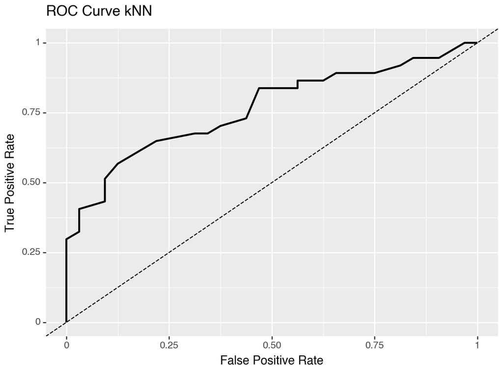

```
<Figure Size: (640 x 480)>
```

```python
from plotnine import ggplot, aes, geom_line, geom_abline, labs
# ROC and Area under the Curve
prob_dt_1 = knn_pipe_tuned.predict_proba(X_test)
roc_auc_dt_1 = roc_auc_score(y_test, prob_dt_1[:, 1])

# Plotting both ROC Curves
# Binarize the true labels
y_bin = label_binarize(y_test, classes=knn_pipe_tuned.classes_)

# Get predicted probabilities for the positive class
y_probs_1 = knn_pipe_tuned.predict_proba(X_test)[:, 1]

# Calculate the ROC curve for each class separately
fpr, tpr, _ = roc_curve(y_bin, y_probs_1)

# Create a DataFrame for the ROC curve
roc_df = pd.DataFrame({'FPR': fpr, 'TPR': tpr})

# Plot the ROC curve using plotnine
(ggplot(roc_df, aes(x='FPR', y='TPR'))
 + geom_line(size=1)
 + geom_abline(slope=1, intercept=0, linetype='dashed', color='black')
 + labs(title='ROC Curve kNN', x='False Positive Rate', y='True Positive Rate')
)
```

logistic roc graph

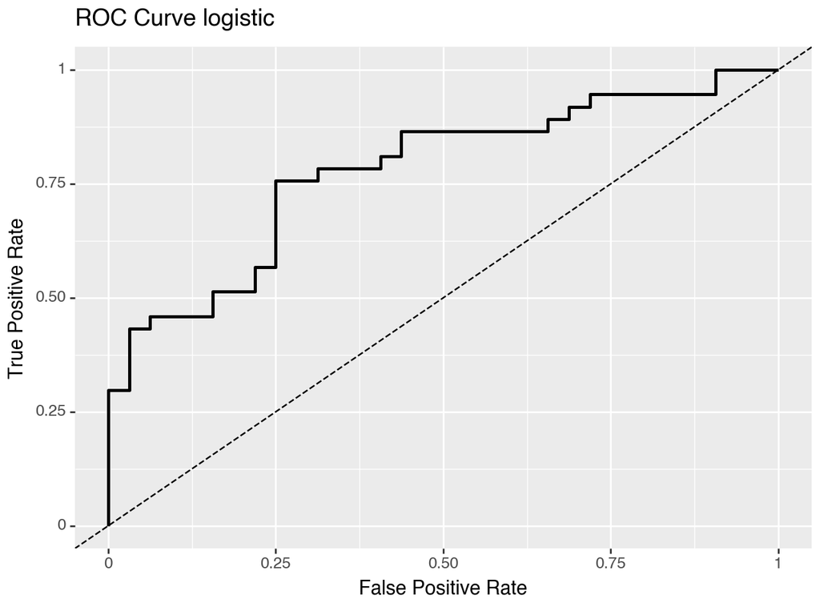

```
<Figure Size: (640 x 480)>
```

```python
from plotnine import ggplot, aes, geom_line, geom_abline, labs
# ROC and Area under the Curve
prob_dt_1 = logistic_regression_pipeline_1.predict_proba(X_test)
roc_auc_dt_1 = roc_auc_score(y_test, prob_dt_1[:, 1])

# Plotting both ROC Curves
# Binarize the true labels
y_bin = label_binarize(y_test, classes=logistic_regression_pipeline_1.classes_)

# Get predicted probabilities for the positive class
y_probs_1 = logistic_regression_pipeline_1.predict_proba(X_test)[:, 1]

# Calculate the ROC curve for each class separately
fpr, tpr, _ = roc_curve(y_bin, y_probs_1)

# Create a DataFrame for the ROC curve
roc_df = pd.DataFrame({'FPR': fpr, 'TPR': tpr})

# Plot the ROC curve using plotnine
(ggplot(roc_df, aes(x='FPR', y='TPR'))
 + geom_line(size=1)
 + geom_abline(slope=1, intercept=0, linetype='dashed', color='black')
 + labs(title='ROC Curve logistic', x='False Positive Rate', y='True Positive Rate')
)
```

decision tree roc graph

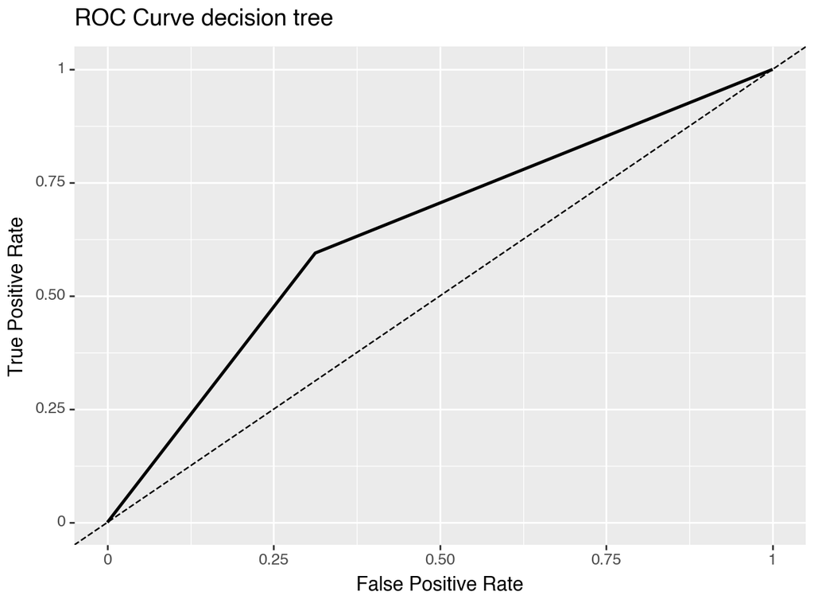

```
<Figure Size: (640 x 480)>
```

```python
from plotnine import ggplot, aes, geom_line, geom_abline, labs
# ROC and Area under the Curve
prob_dt_1 = decision_tree_pipe_tuned.predict_proba(X_test)
roc_auc_dt_1 = roc_auc_score(y_test, prob_dt_1[:, 1])

# Plotting both ROC Curves
# Binarize the true labels
y_bin = label_binarize(y_test, classes=decision_tree_pipe_tuned.classes_)

# Get predicted probabilities for the positive class
y_probs_1 = decision_tree_pipe_tuned.predict_proba(X_test)[:, 1]

# Calculate the ROC curve for each class separately
fpr, tpr, _ = roc_curve(y_bin, y_probs_1)

# Create a DataFrame for the ROC curve
roc_df = pd.DataFrame({'FPR': fpr, 'TPR': tpr})

# Plot the ROC curve using plotnine
(ggplot(roc_df, aes(x='FPR', y='TPR'))
 + geom_line(size=1)
 + geom_abline(slope=1, intercept=0, linetype='dashed', color='black')
 + labs(title='ROC Curve decision tree', x='False Positive Rate', y='True Positive Rate')
)
```

Part Two: Metrics Consider the following metrics:

True Positive Rate or Recall or Sensitivity = Of the observations that are truly Class A, how many were predicted to be Class A?

Precision or Positive Predictive Value = Of all the observations classified as Class A, how many of them were truly from Class A?

True Negative Rate or Specificity or Negative Predictive Value = Of all the observations classified as NOT Class A, how many were truly NOT Class A?

Compute each of these metrics (cross-validated) for your three models (KNN, Logistic Regression, and Decision Tree) in Part One.

```python
from sklearn.model_selection import cross_val_score
from sklearn.metrics import make_scorer, recall_score
```

Knn

```python
#recall
knn_recall_scorer = make_scorer(recall_score, pos_label=1)

recall_scores = cross_val_score(knn_pipe_tuned, X, y, cv=5, scoring=knn_recall_scorer)

print("Mean Recall:", recall_scores.mean())
```

```
Mean Recall: 0.8213793103448277
```

```python
#precision
knn_precision_scorer = make_scorer(precision_score, pos_label=1)

precision_scores = cross_val_score(knn_pipe_tuned, X, y, cv=5, scoring=knn_precision_scorer)

print("Mean Precision:", precision_scores.mean())
```

```
Mean Precision: 0.7747221469232854
```

```python
#true negative

knn_tnr_scorer = make_scorer(lambda y, y_pred: confusion_matrix(y, y_pred)[0, 0] / (confusion_matrix(y, y_pred)[0, 0] + confusion_matrix(y, y_pred)[0, 1]), greater_is_better=True)

tnr_scores = cross_val_score(knn_pipe_tuned, X, y, cv=5, scoring=knn_tnr_scorer)

print("Mean TNR:", tnr_scores.mean())
```

```
Mean TNR: 0.7236923076923076
```

logistic

```python
#recall
log_recall_scorer = make_scorer(recall_score, pos_label=1)

recall_scores = cross_val_score(logistic_regression_pipeline_1, X, y, cv=5, scoring=log_recall_scorer)

print("Mean Recall:", recall_scores.mean())
```

```
Mean Recall: 0.8220689655172414
```

```python
#precision
log_precision_scorer = make_scorer(precision_score, pos_label=1)

precision_scores = cross_val_score(logistic_regression_pipeline_1, X, y, cv=5, scoring=log_precision_scorer)

print("Mean Precision:", precision_scores.mean())
```

```
Mean Precision: 0.7928756530825497
```

```python
#true negative

log_tnr_scorer = make_scorer(lambda y, y_pred: confusion_matrix(y, y_pred)[0, 0] / (confusion_matrix(y, y_pred)[0, 0] + confusion_matrix(y, y_pred)[0, 1]), greater_is_better=True)

tnr_scores = cross_val_score(logistic_regression_pipeline_1, X, y, cv=5, scoring=log_tnr_scorer)

print("Mean TNR:", tnr_scores.mean())
```

```
Mean TNR: 0.747076923076923
```

decision tree

```python
#recall
tree_recall_scorer = make_scorer(recall_score, pos_label=1)

recall_scores = cross_val_score(decision_tree_pipe_tuned, X, y, cv=5, scoring=tree_recall_scorer)

print("Mean Recall:", recall_scores.mean())
```

```
Mean Recall: 0.6988505747126437
```

```python
#precision
tree_precision_scorer = make_scorer(precision_score, pos_label=1)

precision_scores = cross_val_score(decision_tree_pipe_tuned, X, y, cv=5, scoring=tree_precision_scorer)

print("Mean Precision:", precision_scores.mean())
```

```
Mean Precision: 0.7306676522849687
```

```python
#true negative

tree_tnr_scorer = make_scorer(lambda y, y_pred: confusion_matrix(y, y_pred)[0, 0] / (confusion_matrix(y, y_pred)[0, 0] + confusion_matrix(y, y_pred)[0, 1]), greater_is_better=True)

tnr_scores = cross_val_score(decision_tree_pipe_tuned, X, y, cv=5, scoring=tree_tnr_scorer)

print("Mean TNR:", tnr_scores.mean())
```

```
Mean TNR: 0.7000000000000001
```

Part Three: Discussion Suppose you have been hired by a hospital to create classification models for heart attack risk.

The following questions give a possible scenario for why the hospital is interested in these models. For each one, discuss:

Which metric(s) you would use for model selection and why.

Which of your final models (Part One Q1-3) you would recommend to the hospital, and why.

What score you should expect for your chosen metric(s) using your chosen model to predict future observations.

Q1 The hospital faces severe lawsuits if they deem a patient to be low risk, and that patient later experiences a heart attack.

Since hospital will get lawsuits if they failed to identify a patient, the hospital will hope to obtain a low false negative. Therefore, they should aim for recall as their target metrics, as high recall indicates fewer false negatives.

I will recommend the company to use logistic regression or knn as it essentially both did excellent on generating a high recall score.

Q2 The hospital is overfull, and wants to only use bed space for patients most in need of monitoring due to heart attack risk.

Since hospital is overfull, they would want to priortize patient that is actuaclly in risk for heart attack. Therefore they want to rely on metrics that correctly identify the patients in risk, which is Precision.

I will recommend the company to use logistic regression again as it has the highest precision score.

Q3 The hospital is studying root causes of heart attacks, and would like to understand which biological measures are associated with heart attack risk.

Only decision tree can do this job in my opinion. Decision tree model is able to classify target based on variables. For instance, it could tell us how high of a chol someone needs to have to to be considered as high risk. With different variables being judged based on their level, hospital can understand which biological measure are more associated with heart attack.

Q4 The hospital is training a new batch of doctors, and they would like to compare the diagnoses of these doctors to the predictions given by the algorithm to measure the ability of new doctors to diagnose patients.

In this scenerio, I think the hospital will want to make sure the new doctor to be able to diagnose correctly. So we want the new doctor to be able to identify as many patients as possible. Therefore, they should focus on Precision.

I will recommend the company to use lofistic regression as it has the highest precision score.

Part Four: Validation Before sharing the dataset with you, I set aside a random 10% of the observations to serve as a final validation set.

ha_validation = pd.read_csv(“https://www.dropbox.com/s/jkwqdiyx6o6oad0/heart_attack_validation.csv?dl=1”)

Use each of your final models in Part One Q1-3, predict the target variable in the validation dataset.

For each, output a confusion matrix, and report the ROC AUC, the precision, and the recall.

Compare these values to the cross-validated estimates you reported in Part One and Part Two. Did our measure of model success turn out to be approximately correct for the validation data?

```python
ha_validation = pd.read_csv("https://www.dropbox.com/s/jkwqdiyx6o6oad0/heart_attack_validation.csv?dl=1")
```

```python
ha_validation ['sex'] = ha_validation ['sex'].astype(str)
ha_validation ['cp'] = ha_validation ['cp'].astype(str)
ha_validation ['restecg'] = ha_validation ['restecg'].astype(str)
```

```python
X_1 = ha_validation.drop(['output'], axis = 1)
y_1 = ha_validation["output"]
```

knn

```python
y_pred_KNN = knn_pipe_tuned.predict(X_1)
conf_matrix = confusion_matrix(y_1, y_pred_KNN)
conf_matrix
```

```
array([[10,  1],
       [ 7, 12]])
```

```python
#roc_auc
y_prob = knn_pipe_tuned.predict_proba(X_1)[:,1]
roc_auc_score(y_1,y_prob)
```

```
0.9138755980861244
```

```python
#recall
knn_recall_1 = recall_score(y_1, y_pred_KNN)
knn_recall_1
```

```
0.631578947368421
```

```python
#precision
knn_prec1 = precision_score(y_1, y_pred_KNN)
knn_prec1
```

```
0.9230769230769231
```

logistic

```python
y_pred_log = logistic_regression_pipeline_1.predict(X_1)
conf_matrix = confusion_matrix(y_1, y_pred_log)
conf_matrix
```

```
array([[ 9,  2],
       [ 5, 14]])
```

```python
#roc_auc
y_prob = logistic_regression_pipeline_1.predict_proba(X_1)[:,1]
roc_auc_score(y_1,y_prob)
```

```
0.8803827751196172
```

```python
#recall
log_recall_1 = recall_score(y_1, y_pred_log)
log_recall_1
```

```
0.7368421052631579
```

```python
#precision
log_prec1 = precision_score(y_1, y_pred_log)
log_prec1
```

```
0.875
```

decision tree

```python
y_pred_tree = decision_tree_pipe_tuned.predict(X_1)
conf_matrix = confusion_matrix(y_1, y_pred_tree)
conf_matrix
```

```
array([[ 6,  5],
       [ 7, 12]])
```

```python
#roc_auc
y_prob = decision_tree_pipe_tuned.predict_proba(X_1)[:,1]
roc_auc_score(y_1,y_prob)
```

```
0.5885167464114832
```

```python
#recall
tree_recall_1 = recall_score(y_1, y_pred_tree)
knn_recall_1
```

[output not shown]

```python
#precision
tree_prec1 = precision_score(y_1, y_pred_tree)
tree_prec1
```

```
0.7058823529411765
```

For both knn and logistic, my roc_auc is higher than part I by a decent amount, while decision tree is doing worse than part I. I would say my models turn out to be approximately correct, as most of my recall/precision measure is above 0.7.

Part Five: Cohen’s Kappa Another common metric used in classification is Cohen’s Kappa.

Use online resources to research this measurement. Calculate it for the models from Part One, Q1-3, and discuss reasons or scenarios that would make us prefer to use this metric as our measure of model success. Do your conclusions from above change if you judge your models using Cohen’s Kappa instead? Does this make sense?

```python
from sklearn.metrics import cohen_kappa_score
```

```python
#knn
kappa_score = cohen_kappa_score(y_test, knn_pred1)
kappa_score
```

```
0.42452043369474557
```

```python
#log
kappa_score = cohen_kappa_score(y_test, log_pred1)
kappa_score
```

```
0.3669724770642202
```

```python
#decision tree
kappa_score = cohen_kappa_score(y_test, tree_pred1)
kappa_score
```

```
0.27914751358127865
```

The kappa statistic is frequently used to test interrater reliability. Therefore, for part 3 q 4 when asking for compare the diagnoses of new doctors to the predictions given by the algorithm to measure the ability of new doctors to diagnose patients, this measurement will be an excellent choice.

Using the kappa metrics, my three models don’t seem to do so well when we are accessing it with recall, precision. The three models range from .27 to .42. This suggests that the three model can only be interpretated as fair. I think this makes sense. Unlike recall, precision, specificity, kappa is designed to access different rater reliability, rather than predicitivity.